# Regressão Logística

GUILHERME OLIVEIRA CASAGRANDE

2023-11-21

Regresão logística serve para prever uma variável y categorizada

- Duas categorias: logis binária (choveu ou não choveu)
- + que 2: logis multinominal (níveis de classificação de cliente de seguro)
- categorias ordenadas: logis ordinal

Lendo a tabela de confusão

- Verdadeiro positivo (VP) e negativo (VN): previsões corretas
- Falso negativo (FN): o modelo detecta um cliente como fiel, mas é churn (pior erro, nesse caso)
- Falso positivo (FP): o modelo detecta um cliente como churn, mas é fiel (erro bom, nesse caso)
- Acurácia: $VP + VN$ (quantos acertos o modelo fez no total)
- Sensibilidade: $VP / (VP + FN)$ (quantas previsões corretas são válidas)
- Especificidade: $VN / (VN + FP)$ (quantas previsões falsas são válidas)
- Precisão: $VP / (VP + FP)$ (de todas as previsão positivas, quantas foram acertos)

| Observados x Previstos | Churn (0) (sucecsso) | Não churn (1 - churn) (fracasso) |
| --- | --- | --- |
| Churn (0) | ACERTO | FALSO POSITIVO |
| Não Churn (1 - churn) | FALSO NEGATIVO (não detectou churn!) | ACERTO |

Probabilidade de sucesso do modelo ser capaz de fazer uma previsão correta

$$p = exp(a + bx) / (1 + exp(a + bx))$$
por exemplo, a probabilidade de sucesso de ser churn entre 750 acessos se a fórmula for $ln(p / (1 - p)) = 4,0343 - 0,0042 * acessos$

$$p = exp(4,0343 - 0,0042 * 750) / (1 + exp(4,0343 - 0,0042 * 750)) =
0,7077124936$$
E a medida que o número de acessos aumenta, menor a chance de sucesso (b é negativo), ou seja menor a chance de ser um churn

## Exemplo do Churn

A ideia é se concentrar no churn voluntário, que ocorre devido a fatores do relacionamento empresa-cliente. Já que são variáveis controláveis pelas empresas.

Identificar as causas do churn pode ajudar os gestores a tomar melhores decisões alinhadas com as estratégias para que depois o marketing trabalhe para reter o cliente ou mesmo atrair os novos.

### Etapa descritiva

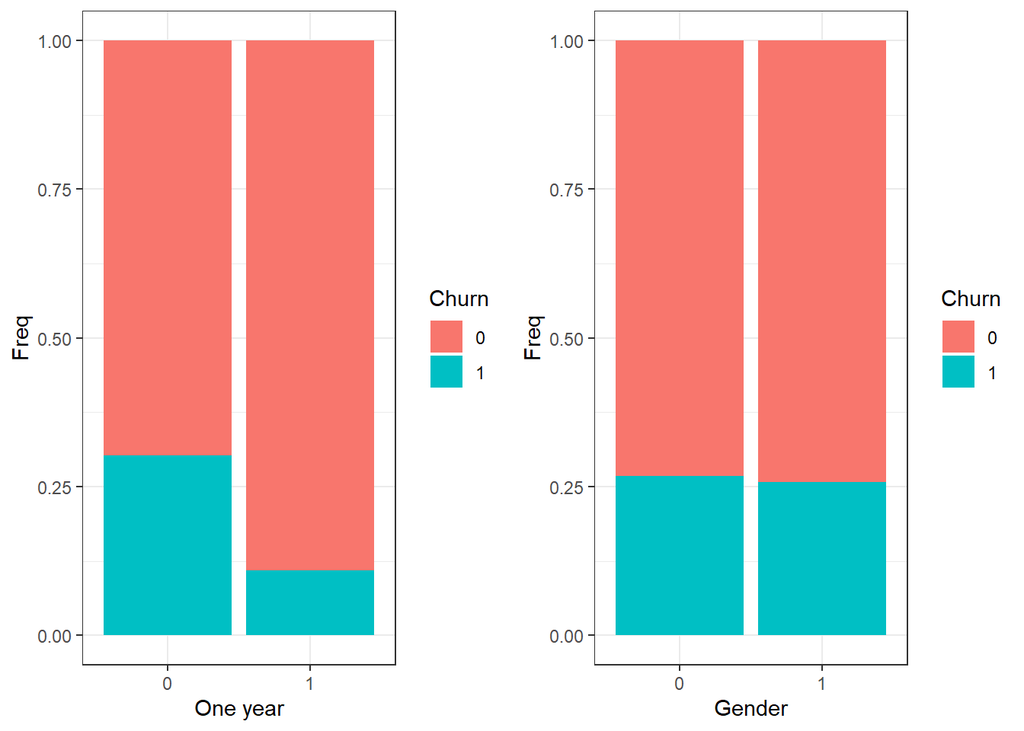

O gráfico de colunas empilhadas mostra que a variável “contrato anual” é uma variável que diferencia os consumidores retidos e perdidos, enquanto que a variável sexo não parece discriminar os dois grupos.

### O Modelo Logístico

Modelo logístico preliminar

|  | Estimate | Std. Error | z value | Pr(>\|z\|) |
| --- | --- | --- | --- | --- |
| (Intercept) | -4.39 | 0.29 | -14.91 | 0.00 |
| gender | -0.05 | 0.08 | -0.65 | 0.51 |
| Dependents | -0.29 | 0.10 | -3.02 | 0.00 |
| PhoneService | -0.41 | 0.15 | -2.73 | 0.01 |
| StreamingTV | 0.17 | 0.09 | 2.04 | 0.04 |
| DSL | 0.63 | 0.16 | 3.98 | 0.00 |
| `Fiber optic` | 1.62 | 0.15 | 10.54 | 0.00 |
| `Month-to-month` | 2.87 | 0.21 | 13.92 | 0.00 |
| `One year` | 1.37 | 0.22 | 6.11 | 0.00 |
| `Electronic check` | 0.73 | 0.11 | 6.35 | 0.00 |
| `Mailed check` | 0.39 | 0.14 | 2.83 | 0.00 |
| `Bank transfer (automatic)` | 0.11 | 0.14 | 0.78 | 0.44 |

A equação logística se escreve da seguinte maneira

$$log(sucesso/fracasso) = -4.39 -0.05*
Gender -0.29*Dependents ...$$

em que o log utilizado é o logaritmo natural e o quociente $sucesso/fracasso$ indica o quociente da probabilidade de sucesso **p** pela probabilidade de fracasso **1-p**.

Os coeficientes negativos mostram que a probabilidade de churn diminui na ocorrência da variável dummy. Exemplo: ter dependentes diminui a probabilidade de churn.

Coeficientes positivos indicam que a probabilidade de churn irá aumentar.

A chance de churn, em média, dado que o cliente tem dependentes é dada pela expressão $exp(-0.29) = 0.75 = 75%$.

O valor de comparação será sempre o valor 1. Nesse caso, ter dependentes diminui a chance de churn em 25%, em média.

Outro exemplo, para os contratos de 1 ano $exp(1.37) = 3.94$ que subtraindo 1, leva a **294%**. Os contratos anuais aumentam a chance de churn em 294%, em média, quando comparados com os contratos bienais (referência).

Essas análises supõem que as outras variáveis são constantes (ceteris paribus).

### Como criar amostra de treino/aprendizado e teste

Quantidade de churns na amostra de treino

| Var1 | Freq |
| --- | --- |
| 0 | 3462 |
| 1 | 1250 |

```
## [1] 2320   12
```

Quantidade de churns na amostra de teste

| Var1 | Freq |
| --- | --- |
| 0 | 1701 |
| 1 | 619 |

### Treinando o modelo

Modelo logístico com a amostra de treino

|  | Estimate | Std. Error | z value | Pr(>\|z\|) |
| --- | --- | --- | --- | --- |
| (Intercept) | -3.94 | 0.27 | -14.45 | 0.00 |
| gender | -0.03 | 0.08 | -0.33 | 0.74 |
| Dependents | -0.33 | 0.09 | -3.53 | 0.00 |
| PhoneService | -0.42 | 0.14 | -2.94 | 0.00 |
| StreamingTV | 0.19 | 0.08 | 2.29 | 0.02 |
| DSL | 0.49 | 0.15 | 3.18 | 0.00 |
| `Fiber optic` | 1.37 | 0.15 | 9.13 | 0.00 |
| `Month-to-month` | 2.70 | 0.18 | 14.73 | 0.00 |
| `One year` | 1.12 | 0.20 | 5.51 | 0.00 |
| `Electronic check` | 0.66 | 0.11 | 5.77 | 0.00 |
| `Mailed check` | 0.34 | 0.14 | 2.51 | 0.01 |
| `Bank transfer (automatic)` | 0.09 | 0.13 | 0.68 | 0.50 |

A tabela acima mostra outra modelagem para o problema com a partição (treino/teste), sendo realizada dentro da linguagem R. Isso explica porque esses coeficientes são diferentes dos coeficientes da primeira modelagem preliminar.

```
## Start:  AIC=4218.58
## Churn ~ gender + Dependents + PhoneService + StreamingTV + DSL +
##     `Fiber optic` + `Month-to-month` + `One year` + `Electronic check` +
##     `Mailed check` + `Bank transfer (automatic)`
##
##                               Df Deviance    AIC
## - gender                       1   4194.7 4216.7
## - `Bank transfer (automatic)`  1   4195.0 4217.0
## <none>                             4194.6 4218.6
## - StreamingTV                  1   4199.8 4221.8
## - `Mailed check`               1   4200.9 4222.9
## - PhoneService                 1   4203.1 4225.1
## - DSL                          1   4205.0 4227.0
## - Dependents                   1   4207.3 4229.3
## - `Electronic check`           1   4228.9 4250.9
## - `One year`                   1   4229.0 4251.0
## - `Fiber optic`                1   4288.6 4310.6
## - `Month-to-month`             1   4577.3 4599.3
##
## Step:  AIC=4216.7
## Churn ~ Dependents + PhoneService + StreamingTV + DSL + `Fiber optic` +
##     `Month-to-month` + `One year` + `Electronic check` + `Mailed check` +
##     `Bank transfer (automatic)`
##
##                               Df Deviance    AIC
## - `Bank transfer (automatic)`  1   4195.2 4215.2
## <none>                             4194.7 4216.7
## - StreamingTV                  1   4199.9 4219.9
## - `Mailed check`               1   4201.0 4221.0
## - PhoneService                 1   4203.2 4223.2
## - DSL                          1   4205.2 4225.2
## - Dependents                   1   4207.4 4227.4
## - `Electronic check`           1   4229.0 4249.0
## - `One year`                   1   4229.1 4249.1
## - `Fiber optic`                1   4288.8 4308.8
## - `Month-to-month`             1   4577.5 4597.5
##
## Step:  AIC=4215.16
## Churn ~ Dependents + PhoneService + StreamingTV + DSL + `Fiber optic` +
##     `Month-to-month` + `One year` + `Electronic check` + `Mailed check`
##
##                      Df Deviance    AIC
## <none>                    4195.2 4215.2
## - StreamingTV         1   4200.4 4218.4
## - `Mailed check`      1   4201.5 4219.5
## - PhoneService        1   4203.6 4221.6
## - DSL                 1   4205.6 4223.6
## - Dependents          1   4207.8 4225.8
## - `One year`          1   4229.6 4247.6
## - `Electronic check`  1   4242.8 4260.8
## - `Fiber optic`       1   4289.2 4307.2
## - `Month-to-month`    1   4578.7 4596.7
```

Modelo logístico ótimo

|  | Estimate | Std. Error | z value | Pr(>\|z\|) |
| --- | --- | --- | --- | --- |
| (Intercept) | -3.91 | 0.26 | -14.97 | 0.00 |
| Dependents | -0.33 | 0.09 | -3.53 | 0.00 |
| PhoneService | -0.42 | 0.14 | -2.92 | 0.00 |
| StreamingTV | 0.19 | 0.08 | 2.28 | 0.02 |
| DSL | 0.49 | 0.15 | 3.18 | 0.00 |
| `Fiber optic` | 1.37 | 0.15 | 9.13 | 0.00 |
| `Month-to-month` | 2.70 | 0.18 | 14.74 | 0.00 |
| `One year` | 1.12 | 0.20 | 5.51 | 0.00 |
| `Electronic check` | 0.61 | 0.09 | 6.88 | 0.00 |
| `Mailed check` | 0.29 | 0.12 | 2.53 | 0.01 |

O modelo ótimo é o modelo sem as variáveis que não possuem relevância estatística. Sobraram apenas aquelas que realmente importam pro cálculo da probabilidade de churn.

### Testando o modelo

Matriz de confusão - Observados vs previstos

|  | 0 | 1 |
| --- | --- | --- |
| 0 | 1272 | 429 |
| 1 | 154 | 465 |

```
## A acurácia do modelo é de: 75 %.
```

```
## A sensibilidade do modelo é de: 75 %.
```

```
## A precisão do modelo é de: 52 %.
```

```
## [1] "Calculating AUC ..."
## [1] "(AUC) Sorting data ..."
## [1] "(AUC) Calculating ranks ..."
## [1] "AUC: 82.3584245321815"
## [1] "Bootstrapping ROC curves"
## [1] "Eval AUC"
## [1] "Producing ROC plot"
```

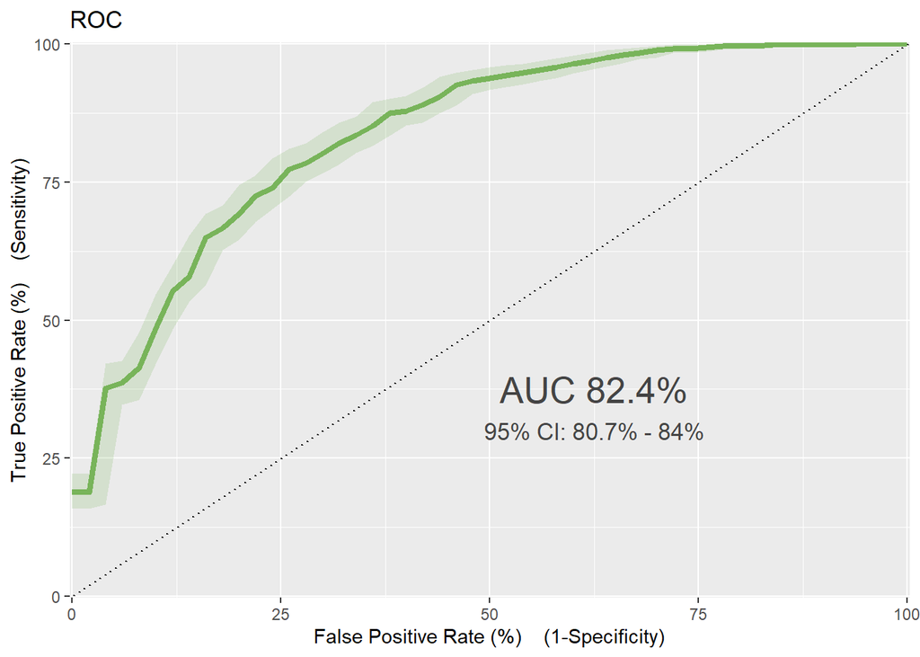

Como a discriminação é 82.4% (realista), o modelo testado tem uma excelente discriminação dos clientes que cancelaram o contrato (churn) e dos que não cancelaram (retidos). A discriminação do modelo é algum valor entre 80.7% e 84% com 95% de confiança. - ROC abaixo de 0.5: não existe discrimininação - de 0.7 a 0.8: discr aceitável - de 0.8 a 0.9: excelente discriminação - acima de 0.9: acima do comum

# Avaliação das vairáveis

- Análise marginal: olhar cada variável categorizada em relação a referência e as outras variáveis de forma constante
- Razão de chance: quanto a chance aumenta na comparação (ex.: a chance do churn aumenta se ele for mensal, em relação a bienal. Assim como o anual em relação ao bienal, mas é menor que a chance anterior) $exp(razChanceBienal - razChanceMensal)$ e $exp(razChanceBienal - razChanceAnual)$
- Feito apenas na massa de teste